# Agrupamiento Espectral sobre un dataset sintético

Vamos en este ejercicio a hacer un agrupamiento espectral descomponiéndolo en sus partes. Como sabéis, Scikit ofrece ya una implementación de este tipo de agrupamiento. Sin embargo es importante fijar los contenidos pasos a paso sin esperar que una sola llamada a una función nos lo resuelva todo. Vamos a trabajar con una base de datos sintética consistente en 3 círculos concéntricos a los que podemos introducir ruído para las figuras queden desdibujadas.

Este ejercicio está basado en la página del Dr. Juan Camilo Orduz

**Andreu Cantó y Amparo Gálvez**

### Paso 1: Generación del dataset

Preparamos la configuración de colores

```python
import numpy as np
import pandas as pd

import matplotlib.pyplot as plt
import seaborn as sns
sns.set_style('darkgrid', {'axes.facecolor': '.9'})
sns.set_palette(palette='deep')
sns_c = sns.color_palette(palette='deep')
%matplotlib inline

from pandas.plotting import register_matplotlib_converters
register_matplotlib_converters()
```

```python
# Set random state.
rs = np.random.seed(25)

def generate_circle_sample_data(r, n, sigma):
    """Generate circle data with random Gaussian noise."""
    angles = np.random.uniform(low=0, high=2*np.pi, size=n)

    x_epsilon = np.random.normal(loc=0.0, scale=sigma, size=n)
    y_epsilon = np.random.normal(loc=0.0, scale=sigma, size=n)

    x = r*np.cos(angles) + x_epsilon
    y = r*np.sin(angles) + y_epsilon
    return x, y


def generate_concentric_circles_data(param_list):
    """Generates many circle data with random Gaussian noise."""
    coordinates = [
        generate_circle_sample_data(param[0], param[1], param[2])
     for param in param_list
    ]
    return coordinates
```

*Ejercicio 1: Prueba a generar diferentes datasets modificando el parámetro sigma. Para ello modifica la lista 'sigmas' de la caja siguiente. Este parámetro es la desviacion típica de la gaussiana que genera el ruido. Escribe cuál es el efecto de aumentar el valor de sigma y en qué valor se pierde la estructura anular (nota: prueba valores desde 0.05 hasta 0.9).

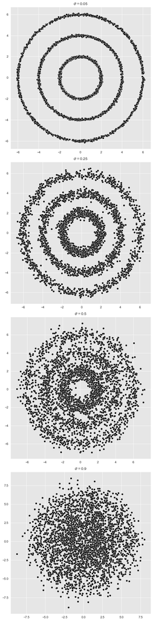

```python
# Set global plot parameters.
plt.rcParams['figure.figsize'] = [8, 8]
plt.rcParams['figure.dpi'] = 80

# Number of points per circle.
n = 1000
# Radius.
r_list =[2, 4, 6]
# Standar deviation (Gaussian noise).
sigmas = [0.05,0.25,0.5,0.9]

param_lists = [[(r, n, sigma) for r in r_list] for sigma in sigmas]
# We store the data on this list.
coordinates_list = []

fig, axes = plt.subplots(len(sigmas), 1, figsize=(7, 28))

for i, param_list in enumerate(param_lists):

    coordinates = generate_concentric_circles_data(param_list)

    coordinates_list.append(coordinates)

    ax = axes[i]

    for j in range(0, len(coordinates)):

        x, y = coordinates[j]
        sns.scatterplot(x=x, y=y, color='black', ax=ax)
        ax.set(title=f'$\sigma$ = {param_list[0][2]}')

plt.tight_layout()
```

Al aumentar sigma vemos que el ruido aumenta, por lo que las circunferencias se van dispersando cada vez más. En sigma=0.5 la circunferencias se pueden intuir pero ya hay demasiado ruido ara que sea 100% claro, en sigma=0.9 es practicamente imposible diferenciarlas.

### Paso 2: Determinación del número de clusters k

Como sabemos, si tenemos un dataset del que no conocemos nada, un método para estimar el posible número de clusters es usar K-Means y construir la gráfica 'elbow' como se vió. Otro es el descomponer espectralmente la matriz laplaciana L y analizar el 'Eigengap', es decir, el primer salto a un valor grande en la secuencia de autovalores ordenados. Vamos a tomar por ahora la primera vía. Consideraremos la inercia como el parámetro indicativo respecto al número de clusters. Vamos a importar k-means y los incluiremos en un bucle para calcular las iniercias en función de k

```
             x         y
0     1.439484 -1.436009
1    -1.670473 -0.983748
2    -0.387913  1.855703
3     0.818219  1.905870
4    -1.627959  1.036084
...        ...       ...
2995  5.659319 -1.963975
2996  2.154165 -5.538608
2997  4.411498 -4.066516
2998 -2.025400  5.590105
2999  5.771603  1.502188

[3000 rows x 2 columns]
```

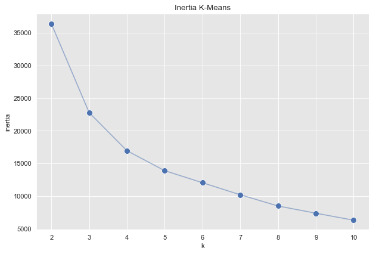

```python
#Damos formato de Frame al primer conjunto de datos generados anteriormente
from itertools import chain

coordinates = coordinates_list[0]

def data_frame_from_coordinates(coordinates):
    """From coordinates to data frame."""
    xs = chain(*[c[0] for c in coordinates])
    ys = chain(*[c[1] for c in coordinates])

    return pd.DataFrame(data={'x': xs, 'y': ys})

data_df = data_frame_from_coordinates(coordinates)

#Procedemos a ejecutar Kmeans
from sklearn.cluster import KMeans

inertias = []


print(data_df)

#Prepara una lista de valores de K desde 2 hasta 10, llámala k_candidates
k_candidates = list(range(2, 11))

#En cada iteración prepara un modelo de Kmeans con el parámetro random_state=42 para
#revisarlo yo fácilmente y con un número de clusters de la lista que has preparado
for k in k_candidates:
    #prepara el modelo
    k_means = KMeans(n_clusters=k, random_state=42)

    #aplica el modelo a la base de datos
    k_means.fit(data_df)

    #añade a la lista de inercias la nueva inercia de este K-Means realizado en la iteracion
    inertias.append(k_means.inertia_)


fig, ax = plt.subplots(figsize=(9, 6))
sns.scatterplot(x=k_candidates, y = inertias, s=80, ax=ax)
#sns.scatterplot(x=[k_candidates[2]], y = [inertias[2]], color=sns_c[3], s=150, ax=ax)
sns.lineplot(x=k_candidates, y = inertias, alpha=0.5, ax=ax)
ax.set(title='Inertia K-Means', ylabel='inertia', xlabel='k');
```

**Cuestión 1** ¿Mirando la curva que te ha salido, qué candidatos podrían ser buenos para establecer el número de clusters K?

La curva nos muestra un codo en k=3, k=4 y k=5, por tanto, unos buenos candidatos para k serían estos.

Vamos a hacer un agrupamiento usando Kmeans con el número elegido de clusters sobre nuestro dataset para ver cómo se comporta

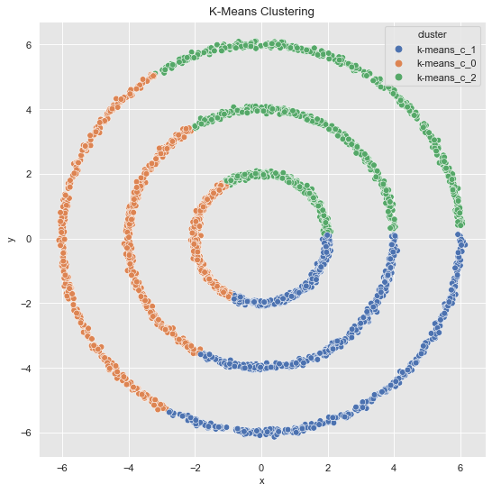

```python
#prepara el modelo con el parámetro random_state=25
k_means = KMeans(n_clusters=3, random_state=25)

#ajusta el moodelo con el dataset
k_means.fit(data_df)

#Usa ahora el método predict para etiquetar los puntos
cluster = k_means.predict(data_df)

cluster = ['k-means_c_' + str(c) for c in cluster]

fig, ax = plt.subplots()
sns.scatterplot(x='x', y='y', data=data_df.assign(cluster = cluster), hue='cluster', ax=ax)
ax.set(title='K-Means Clustering');
```

**Cuestión2**: Valora el agrupamiento que realiza K-Means. ¿Por qué tiene ese comportamiento? (Escribe tu respuesta en esta caja)

El algoritmo k-means no se adapta a la topología de los datos. Utiliza la distancia euclidea para medir la similitud entre puntos y centroides. Esta métrica no es la más adecuada cuando se trabaja con formas no esféricas, como es el caso de los círculos concéntricos.

### Paso 3: Construcción del grafo

Vamos a utilizar K vecinos más próximos. Podemos estudiar con otro tipo de grafos los resultados (grafos epsilon o conectados con distancia decreciente gaussiana)

Para ello vamos a usar sklearn.neighbors.kneighbors_graph que nos devuelve la matriz de dimensión nXn con pesos para los k vecinos más próximos de cada vértice y 0 en el resto. Es pues una matriz de pesos dispersa.

**Importante** La matriz de pesos dispersa que devuelve sklearn.neighbors.kneighbors_graph no es simétrica. Y necesitamos que la matriz de pesos W de la que se calcula la matriz laplaciana **Sí sea simétrica** para que también lo sea esta última. El truco es sumar a la matriz dispersa su traspuesta y dividir los pesos por 2.

```python
from sklearn.neighbors import kneighbors_graph
from scipy import sparse
#numero de vecinos
nn=8

connectivity = kneighbors_graph(X=data_df, n_neighbors=nn, mode='connectivity')
print(connectivity)
# Adjacency Matrix W.   Suma connectivity a su traspuesta y divide entre 2
adjacency_matrix_s = (connectivity + np.transpose(connectivity)) / 2
print("-------")
print()
print(adjacency_matrix_s)
```

[output not shown]

[output cut: 49 more lines]

```
  (2998, 2117)	1.0
  (2998, 2651)	0.5
  (2998, 2926)	1.0
  (2998, 2972)	1.0
  (2998, 2554)	1.0
  (2998, 2542)	1.0
  (2999, 2138)	0.5
  (2999, 2083)	1.0
  (2999, 2303)	1.0
  (2999, 2761)	1.0
  (2999, 2510)	1.0
  (2999, 2367)	1.0
  (2999, 2005)	1.0
  (2999, 2871)	1.0
  (2999, 2527)	1.0
```

Calculamos ahora la matriz laplaciana. Usamos el método sparse.csgraph.laplacian . **Actividad2:** Consulta sus parámetros en el manual de librerias. ¿Qué significa el parámetro 'normed'? Responde aquí

Este parámetro sirve para indicar si la matriz laplaciana se debe normalizar (T) o no (F).

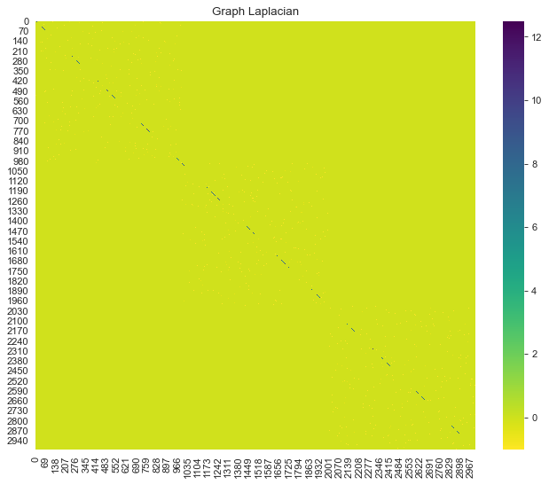

```python
# Graph Laplacian.
graph_laplacian_s = sparse.csgraph.laplacian(csgraph=adjacency_matrix_s, normed=False)

#convierte la matriz en un array usando el método toarray()
graph_laplacian = graph_laplacian_s.toarray()

# Plot the graph Laplacian as heat map.
fig, ax = plt.subplots(figsize=(10, 8))
sns.heatmap(graph_laplacian, ax=ax, cmap='viridis_r')
ax.set(title='Graph Laplacian');
```

### Paso 4: Obtención de los autovalores y autovectores de la matriz laplaciana

```python
from scipy import linalg

eigenvals, eigenvcts = linalg.eig(graph_laplacian)
```

En general los autovalores son números complejos. Sin embargo sabemos que para matrices simétricas, los autovalores son números reales. Compruébalo sacando la lista de valores complejos diferentes de los autovalores. Vemos que el único valor de la parte compleja es 0.

```python
np.unique(np.imag(eigenvals))
```

```
array([-4.07014484e-15,  0.00000000e+00,  4.07014484e-15])
```

Vamos a quitar la parte compleja, que es 0, y vamos a dejar los autovalores con la parte real únicamente

```python
eigenvals = np.real(eigenvals)
eigenvcts = np.real(eigenvcts)
```

Ordenamos de menor a mayor autovalor

```python
from sklearn.preprocessing import normalize


eigenvals_sorted_indices = np.argsort(eigenvals)
eigenvals_sorted = eigenvals[eigenvals_sorted_indices]

#Comprobamos que los tres primeros autovalores son aproximadamente 0
zero_eigenvals_index = np.argwhere(abs(eigenvals_sorted) < 1e-5)
print(zero_eigenvals_index )
print("***************")


#También ordenamos los autovectores

indices = eigenvals_sorted_indices[: 3]


proj_df = pd.DataFrame(eigenvcts[:, indices])

print(proj_df)

proj_df.columns = ['v_' + str(c) for c in proj_df.columns]

#normalizamos la filas
proj_df = normalize(proj_df, norm='l2', axis=1)
print("-+-+-+-+")
print(proj_df)
```

```
[[0]
 [1]
 [2]]
***************
        0         1         2
0     0.0  0.031623  0.000000
1     0.0  0.031623  0.000000
2     0.0  0.031623  0.000000
3     0.0  0.031623  0.000000
4     0.0  0.031623  0.000000
...   ...       ...       ...
2995  0.0  0.000000  0.031623
2996  0.0  0.000000  0.031623
2997  0.0  0.000000  0.031623
2998  0.0  0.000000  0.031623
2999  0.0  0.000000  0.031623

[3000 rows x 3 columns]
-+-+-+-+
[[0. 1. 0.]
 [0. 1. 0.]
 [0. 1. 0.]
 ...
 [0. 0. 1.]
 [0. 0. 1.]
 [0. 0. 1.]]
```

Fíjate en los valores (normalizados) que hemos imprimido de los tres primeros autovectores, correspondientes al autovalor 0. Explica la forma que tienen y qué están indicando con los valores de sus coordenadas **Respuesta:**

La multiplicidad del autovalor 0 es tres vemos que los tres autovectores los datos se van a agrupar en 3 grupos que corresponden con las tres circunferencias que forman los datos. Las coordenadas de los autovectores serán 1 cuando el dato pertenezca al cluster y cero cuando no para cumplir con la propiedad de ortogonalidad.

Vamos a visualizar ahora los autovalores en una gráfica:

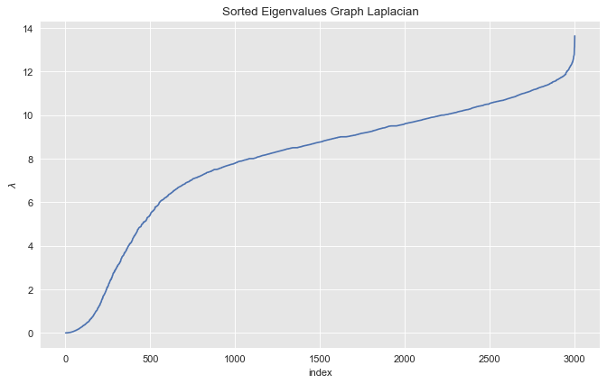

```python
fig, ax = plt.subplots(figsize=(10, 6))
sns.lineplot(x=range(1, eigenvals_sorted_indices.size + 1), y=eigenvals_sorted, ax=ax)
ax.set(title='Sorted Eigenvalues Graph Laplacian', xlabel='index', ylabel=r'$\lambda$');
```

Hay tantos autovalores como dimensión de la matriz, es decir, como datos en el dataset. Sin embargo los más interesants para nosotros son los iniciales que forman un conjunto de valores nulos y el primer valor que se separa sustancialmente de 0 (llamado valor Fidler). Vamos a escalar la gráfica centrándonos en esa zona

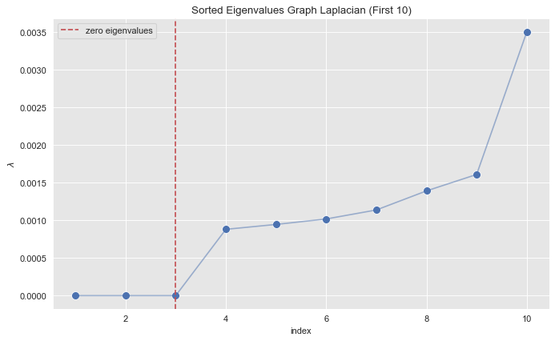

```python
index_lim = 10

fig, ax = plt.subplots(figsize=(10, 6))
sns.scatterplot(x=range(1, eigenvals_sorted_indices[: index_lim].size + 1), y=eigenvals_sorted[: index_lim], s=80, ax=ax)
sns.lineplot(x=range(1, eigenvals_sorted_indices[: index_lim].size + 1), y=eigenvals_sorted[: index_lim], alpha=0.5, ax=ax)
ax.axvline(x=3, color=sns_c[3], label='zero eigenvalues', linestyle='--')
ax.legend()
ax.set(title=f'Sorted Eigenvalues Graph Laplacian (First {index_lim})', xlabel='index', ylabel=r'$\lambda$');
```

Podemos ver que la descomposición espectral nos está indicando con el número de autovalores 0 que existen **Tres** componentes conectadas en este grafo (que coincidirán con los tres círculos concéntricos de la figura). En este ejemplo sintético las cosas están muy claras. Hay claramente tres componentes conexas que son los tres anillos concéntricos. Con datos reales, hay ruído y las cosas no son tan claras como aparecen aquí.

### Paso 5: Uso de KMeans para agrupar los autovectores

Como ya sabemos, debemos considerar ahora la matriz de los autovectores por columnas y agruparlas como si fueran datos por filas. Por el análisis espectral y por la curva de 'elbow' sabemos que k=3 es un valor prometedor (podeis pensar "pero si ya lo sé porque los datos son tres círculos concéntricos". Pero daros cuenta que en general NO SABEMOS A PRIORI la distribución de los datos, así que la especulación de que k=3 debe venir por estos métodos de análisis (espectral y 'elbow'). Preparamos así una matriz con los autovectores T de dimensión n X 3

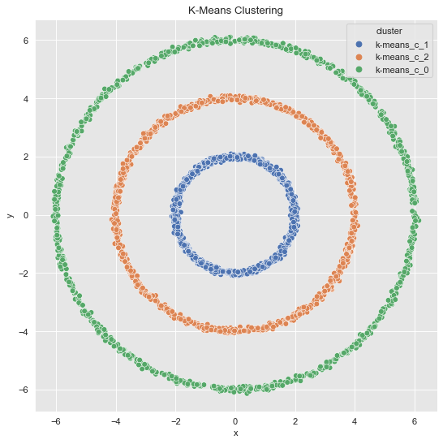

```python
#Prepara KMeans con el modelo para 3 clusters , usa random_state=25
k_means = KMeans(n_clusters=3, random_state=25)
#Ajusta el modelo con nuestro dataset de componentes de autovectores
k_means.fit(proj_df)

#Predice las etiquetas de nuestros puntos
cluster_autoval = k_means.predict(proj_df)

cluster_autoval = ['k-means_c_' + str(c) for c in cluster_autoval]

fig, ax = plt.subplots()
sns.scatterplot(x='x', y='y', data=data_df.assign(cluster = cluster_autoval), hue='cluster', ax=ax)
ax.set(title='K-Means Clustering');
```

**Cuestión 3:** Valora los resultados del agrupamiento espectral para este dataset

Cuando se obtiene un buen agrupamiento con K-Means, en este caso, con K=3, significa que el algoritmo ha identificado grupos que comparten características similares y que están separados entre sí. Por tanto, como vemos los tres clusters que se corresponden con las tres circunferencias concentricas correspondería a un buen agrupamiento.

**Actividad 3:** **Realiza todos los pasos con los datasets generados para $$\sigma = 0.25$$ y $$\sigma = 0.5$$**

$$\sigma = 0.25$$

```
             x         y
0    -0.467680  2.564296
1    -1.268813  0.741919
2     0.216857  1.800105
3     1.654558  1.613797
4    -1.447274 -1.783832
...        ...       ...
2995 -3.543896  5.231385
2996 -5.566836 -2.644454
2997  1.851804  5.810061
2998  5.191441 -2.503097
2999 -3.974296  4.571257

[3000 rows x 2 columns]
```

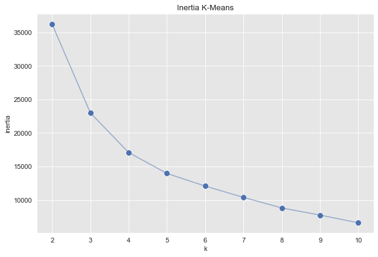

```python
coordinates = coordinates_list[1]

def data_frame_from_coordinates(coordinates):
    """From coordinates to data frame."""
    xs = chain(*[c[0] for c in coordinates])
    ys = chain(*[c[1] for c in coordinates])

    return pd.DataFrame(data={'x': xs, 'y': ys})

data_df = data_frame_from_coordinates(coordinates)

#Procedemos a ejecutar Kmeans
from sklearn.cluster import KMeans

inertias = []


print(data_df)

#Prepara una lista de valores de K desde 2 hasta 10, llámala k_candidates
k_candidates = list(range(2, 11))

#En cada iteración prepara un modelo de Kmeans con el parámetro random_state=42 para
#revisarlo yo fácilmente y con un número de clusters de la lista que has preparado
for k in k_candidates:
    #prepara el modelo
    k_means = KMeans(n_clusters=k, random_state=42)

    #aplica el modelo a la base de datos
    k_means.fit(data_df)

    #añade a la lista de inercias la nueva inercia de este K-Means realizado en la iteracion
    inertias.append(k_means.inertia_)


fig, ax = plt.subplots(figsize=(9, 6))
sns.scatterplot(x=k_candidates, y = inertias, s=80, ax=ax)
#sns.scatterplot(x=[k_candidates[2]], y = [inertias[2]], color=sns_c[3], s=150, ax=ax)
sns.lineplot(x=k_candidates, y = inertias, alpha=0.5, ax=ax)
ax.set(title='Inertia K-Means', ylabel='inertia', xlabel='k');
```

```python
#prepara el modelo con el parámetro random_state=25
k_means = KMeans(n_clusters=3, random_state=25)

#ajusta el moodelo con el dataset
k_means.fit(data_df)

#Usa ahora el método predict para etiquetar los puntos
cluster = k_means.predict(data_df)

cluster = ['k-means_c_' + str(c) for c in cluster]
```

```python
nn=8

connectivity = kneighbors_graph(X=data_df, n_neighbors=nn, mode='connectivity')
#print(connectivity)
# Adjacency Matrix W.   Suma connectivity a su traspuesta y divide entre 2
adjacency_matrix_s = (connectivity + np.transpose(connectivity)) / 2
#print("-------")
#print()
#print(adjacency_matrix_s)
```

```python
# Graph Laplacian.
graph_laplacian_s = sparse.csgraph.laplacian(csgraph=adjacency_matrix_s, normed=False)

#convierte la matriz en un array usando el método toarray()
graph_laplacian = graph_laplacian_s.toarray()
```

```python
eigenvals, eigenvcts = linalg.eig(graph_laplacian)
np.unique(np.imag(eigenvals))
eigenvals = np.real(eigenvals)
eigenvcts = np.real(eigenvcts)
eigenvals_sorted_indices = np.argsort(eigenvals)
eigenvals_sorted = eigenvals[eigenvals_sorted_indices]

#Comprobamos que los tres primeros autovalores son aproximadamente 0
zero_eigenvals_index = np.argwhere(abs(eigenvals_sorted) < 1e-5)
print(zero_eigenvals_index )
print("***************")


#También ordenamos los autovectores

indices = eigenvals_sorted_indices[: 7]


proj_df = pd.DataFrame(eigenvcts[:, indices])

print(proj_df)

proj_df.columns = ['v_' + str(c) for c in proj_df.columns]

#normalizamos la filas
proj_df = normalize(proj_df, norm='l2', axis=1)
print("-+-+-+-+")
print(proj_df)
```

```
[[0]]
***************
             0         1         2         3         4         5         6
0    -0.018257 -0.014343 -0.015937 -0.000336  0.001767  0.002653  0.002123
1    -0.018257 -0.013821 -0.015645  0.000038  0.000685 -0.007264  0.010476
2    -0.018257 -0.014393 -0.015650 -0.000415  0.001961  0.004866 -0.000154
3    -0.018257 -0.014402 -0.013498 -0.000700  0.002538  0.012801 -0.009093
4    -0.018257 -0.015106 -0.023928 -0.000333  0.003638 -0.017290 -0.000335
...        ...       ...       ...       ...       ...       ...       ...
2995 -0.018257  0.014381  0.004446 -0.000470 -0.042252 -0.007576 -0.005959
2996 -0.018257  0.022783  0.001925  0.044021 -0.005970 -0.008442 -0.017296
2997 -0.018257  0.025489 -0.001673 -0.037781 -0.030754 -0.009950 -0.019749
2998 -0.018257  0.032843 -0.006627 -0.024114  0.029229  0.009131  0.016512
2999 -0.018257  0.012722  0.005071  0.005166 -0.039640 -0.005846 -0.002095

[3000 rows x 7 columns]
-+-+-+-+
[[-0.64236392 -0.50464456 -0.56072123 ...  0.06217233  0.09332899
   0.07468969]
 [-0.59800371 -0.45268585 -0.51245135 ...  0.02244654 -0.23791914
   0.3431469 ]
 [-0.64026523 -0.50474775 -0.54881967 ...  0.06878141  0.17063168
  -0.00541063]
 ...
 [-0.29432094  0.41089511 -0.0269774  ... -0.49577139 -0.16039906
  -0.31836962]
 [-0.32036498  0.5763037  -0.11628759 ...  0.51288646  0.16023008
   0.28974178]
 [-0.39307019  0.27389294  0.1091656  ... -0.85341483 -0.12585954
  -0.04510846]]
```

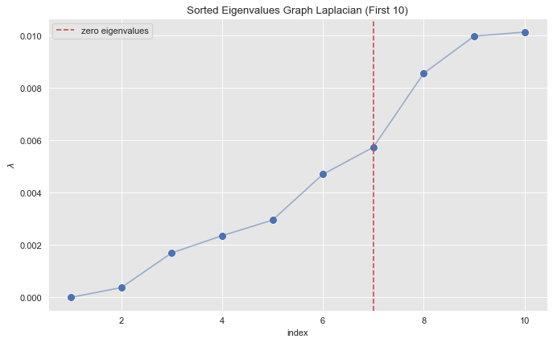

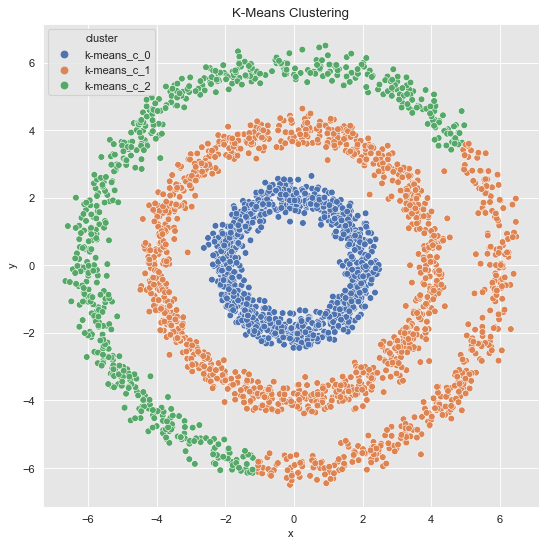

```python
index_lim = 10

fig, ax = plt.subplots(figsize=(10, 6))
sns.scatterplot(x=range(1, eigenvals_sorted_indices[: index_lim].size + 1), y=eigenvals_sorted[: index_lim], s=80, ax=ax)
sns.lineplot(x=range(1, eigenvals_sorted_indices[: index_lim].size + 1), y=eigenvals_sorted[: index_lim], alpha=0.5, ax=ax)
ax.axvline(x=7, color=sns_c[3], label='zero eigenvalues', linestyle='--')
ax.legend()
ax.set(title=f'Sorted Eigenvalues Graph Laplacian (First {index_lim})', xlabel='index', ylabel=r'$\lambda$');

#Prepara KMeans con el modelo para 3 clusters , usa random_state=25
k_means = KMeans(n_clusters=3, random_state=25)
#Ajusta el modelo con nuestro dataset de componentes de autovectores
k_means.fit(proj_df)

#Predice las etiquetas de nuestros puntos
cluster_autoval = k_means.predict(proj_df)

cluster_autoval = ['k-means_c_' + str(c) for c in cluster_autoval]

fig, ax = plt.subplots()
sns.scatterplot(x='x', y='y', data=data_df.assign(cluster = cluster_autoval), hue='cluster', ax=ax)
ax.set(title='K-Means Clustering');
```

$$\sigma = 0.5$$

```
             x         y
0     0.946943 -2.028648
1    -0.680554 -1.696670
2     1.508839 -1.630035
3     0.191278  2.035810
4     0.833297 -2.416864
...        ...       ...
2995 -4.594673  4.106042
2996  6.819322  2.286239
2997  0.663698 -6.563105
2998  1.750170 -5.529059
2999  5.285659 -3.685630

[3000 rows x 2 columns]
```

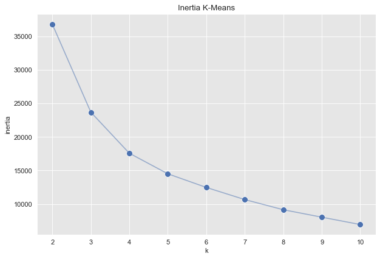

```python
coordinates = coordinates_list[2]

def data_frame_from_coordinates(coordinates):
    """From coordinates to data frame."""
    xs = chain(*[c[0] for c in coordinates])
    ys = chain(*[c[1] for c in coordinates])

    return pd.DataFrame(data={'x': xs, 'y': ys})

data_df = data_frame_from_coordinates(coordinates)

#Procedemos a ejecutar Kmeans
from sklearn.cluster import KMeans

inertias = []


print(data_df)

#Prepara una lista de valores de K desde 2 hasta 10, llámala k_candidates
k_candidates = list(range(2, 11))

#En cada iteración prepara un modelo de Kmeans con el parámetro random_state=42 para
#revisarlo yo fácilmente y con un número de clusters de la lista que has preparado
for k in k_candidates:
    #prepara el modelo
    k_means = KMeans(n_clusters=k, random_state=42)

    #aplica el modelo a la base de datos
    k_means.fit(data_df)

    #añade a la lista de inercias la nueva inercia de este K-Means realizado en la iteracion
    inertias.append(k_means.inertia_)


fig, ax = plt.subplots(figsize=(9, 6))
sns.scatterplot(x=k_candidates, y = inertias, s=80, ax=ax)
#sns.scatterplot(x=[k_candidates[2]], y = [inertias[2]], color=sns_c[3], s=150, ax=ax)
sns.lineplot(x=k_candidates, y = inertias, alpha=0.5, ax=ax)
ax.set(title='Inertia K-Means', ylabel='inertia', xlabel='k');
```

```python
#prepara el modelo con el parámetro random_state=25
k_means = KMeans(n_clusters=3, random_state=25)

#ajusta el moodelo con el dataset
k_means.fit(data_df)

#Usa ahora el método predict para etiquetar los puntos
cluster = k_means.predict(data_df)

cluster = ['k-means_c_' + str(c) for c in cluster]
```

```python
nn=8

connectivity = kneighbors_graph(X=data_df, n_neighbors=nn, mode='connectivity')
#print(connectivity)
# Adjacency Matrix W.   Suma connectivity a su traspuesta y divide entre 2
adjacency_matrix_s = (connectivity + np.transpose(connectivity)) / 2
#print("-------")
#print()
#print(adjacency_matrix_s)
```

```python
# Graph Laplacian.
graph_laplacian_s = sparse.csgraph.laplacian(csgraph=adjacency_matrix_s, normed=False)

#convierte la matriz en un array usando el método toarray()
graph_laplacian = graph_laplacian_s.toarray()
```

```python
eigenvals, eigenvcts = linalg.eig(graph_laplacian)
np.unique(np.imag(eigenvals))
eigenvals = np.real(eigenvals)
eigenvcts = np.real(eigenvcts)
eigenvals_sorted_indices = np.argsort(eigenvals)
eigenvals_sorted = eigenvals[eigenvals_sorted_indices]

#Comprobamos que los tres primeros autovalores son aproximadamente 0
zero_eigenvals_index = np.argwhere(abs(eigenvals_sorted) < 1e-5)
print(zero_eigenvals_index )
print("***************")


#También ordenamos los autovectores

indices = eigenvals_sorted_indices[: 7]


proj_df = pd.DataFrame(eigenvcts[:, indices])

print(proj_df)

proj_df.columns = ['v_' + str(c) for c in proj_df.columns]

#normalizamos la filas
proj_df = normalize(proj_df, norm='l2', axis=1)
print("-+-+-+-+")
print(proj_df)
```

```
[[0]]
***************
             0         1         2         3         4         5         6
0    -0.018257  0.000553  0.019818 -0.027233 -0.014473  0.007484  0.035137
1    -0.018257 -0.013591  0.009465 -0.017981 -0.021982 -0.002132  0.029837
2    -0.018257  0.005288  0.020006 -0.027721 -0.010803  0.004912  0.029573
3    -0.018257  0.013548 -0.015725 -0.003724 -0.026905  0.004160 -0.034606
4    -0.018257 -0.002962  0.020444 -0.022069 -0.013507  0.011321  0.031574
...        ...       ...       ...       ...       ...       ...       ...
2995 -0.018257 -0.007441 -0.029693 -0.006859  0.032501  0.025184  0.016884
2996 -0.018257  0.027872  0.008324  0.015776  0.022367 -0.029335  0.000335
2997 -0.018257 -0.014721  0.027237  0.023186 -0.002408  0.033176 -0.016562
2998 -0.018257 -0.007766  0.029033  0.010273  0.006421  0.035318 -0.014370
2999 -0.018257  0.011537  0.028195 -0.008265  0.037700  0.013537 -0.021594

[3000 rows x 7 columns]
-+-+-+-+
[[-0.33512027  0.01014832  0.36377214 ... -0.26565491  0.13736697
   0.644944  ]
 [-0.37995326 -0.28284688  0.19696781 ... -0.45747378 -0.04437317
   0.62093191]
 [-0.36187615  0.10480813  0.39654249 ... -0.21412846  0.09736046
   0.58616351]
 ...
 [-0.32223453 -0.25982409  0.48071336 ... -0.04250145  0.58554065
  -0.29231133]
 [-0.34276428 -0.14580071  0.54505685 ...  0.1205431   0.66306586
  -0.26978806]
 [-0.31308632  0.19783434  0.48350338 ...  0.64649717  0.23213859
  -0.37030894]]
```

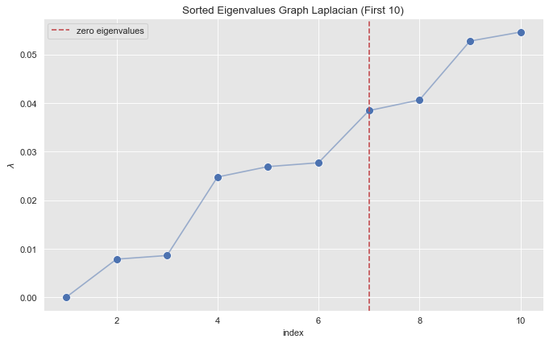

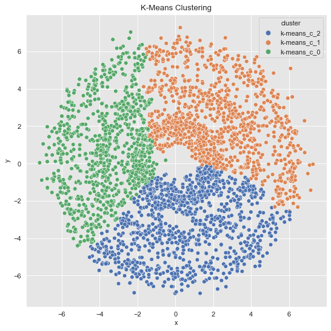

```python
index_lim = 10

fig, ax = plt.subplots(figsize=(10, 6))
sns.scatterplot(x=range(1, eigenvals_sorted_indices[: index_lim].size + 1), y=eigenvals_sorted[: index_lim], s=80, ax=ax)
sns.lineplot(x=range(1, eigenvals_sorted_indices[: index_lim].size + 1), y=eigenvals_sorted[: index_lim], alpha=0.5, ax=ax)
ax.axvline(x=7, color=sns_c[3], label='zero eigenvalues', linestyle='--')
ax.legend()
ax.set(title=f'Sorted Eigenvalues Graph Laplacian (First {index_lim})', xlabel='index', ylabel=r'$\lambda$');

#Prepara KMeans con el modelo para 3 clusters , usa random_state=25
k_means = KMeans(n_clusters=3, random_state=25)
#Ajusta el modelo con nuestro dataset de componentes de autovectores
k_means.fit(proj_df)

#Predice las etiquetas de nuestros puntos
cluster_autoval = k_means.predict(proj_df)

cluster_autoval = ['k-means_c_' + str(c) for c in cluster_autoval]

fig, ax = plt.subplots()
sns.scatterplot(x='x', y='y', data=data_df.assign(cluster = cluster_autoval), hue='cluster', ax=ax)
ax.set(title='K-Means Clustering');
```

**Actividad 4** Escribe aquí la valoración de los resultados obtenidos en los dos datasets que acabas de realizar en comparación con el primer dataset

En el caso del primer dataset, los datos están relativamente limpios, con poca o ninguna interferencia de ruido. El algoritmo K-means funciona eficazmente al agrupar los puntos de datos de manera coherente alrededor de los tres anillos concéntricos. Los centroides de los clusters se ajustan bien a la estructura anular de los datos, la separación entre los clusters refleja con precisión la distribución de los anillos concéntricos y la asignación de puntos a clusters es consistente con la verdadera estructura subyacente de los datos.

En los últimos resultados obtenidos, se introduce una cantidad significativa de ruido en los datos. El algoritmo K-means, al ser sensible a los valores atípicos, puede tener dificultades para manejar el ruido, afectando la calidad del agrupamiento. Los centroides de los clusters están influenciados por la presencia de puntos ruidosos, lo que afecta su posición; los puntos ruidosos son asignados a clusters, introduciendo confusiones en la agrupación y la estructura anular es menos clara en la agrupación debido a la interferencia del ruido.

## Agrupamiento Espectral con la librería Scikit

Aunque hemos hecho todos los pasos en este ejercico para comprender cómo se produce al agrupamiento espectral, existe una instrucción en la librería Scikit que realiza todos los pasos anteriormente dados.

**Cuestión 4:** Consulta la librería y describe lo que significan las opciones que se usan en la caja de abajo

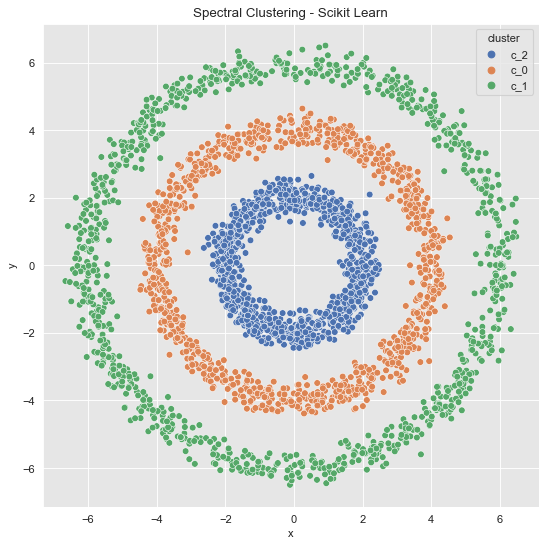

```python
from sklearn.cluster import SpectralClustering

#damos formato de dataframe a uno de los conjuntos de datos (el del medio)
data_df = data_frame_from_coordinates(coordinates_list[1])

spec_cl = SpectralClustering(
    n_clusters=3,
    random_state=25,
    n_neighbors=8,
    affinity='nearest_neighbors'
)

data_df['cluster'] = spec_cl.fit_predict(data_df[['x', 'y']])
data_df['cluster'] = ['c_' + str(c) for c in data_df['cluster']]

fig, ax = plt.subplots()
sns.scatterplot(x='x', y='y', data=data_df, hue='cluster', ax=ax)
ax.set(title='Spectral Clustering - Scikit Learn');
```

**n_clusters=** -> Especifica el número de clústeres o grupos en los que se quiere dividir los datos. En este caso, se ha configurado en 3, lo que significa que se intentará agrupar los datos en tres clusters distintos.

**random_state=25** -> Es una semilla para controlar la reproducibilidad de los resultados. Al fijar un valor específico, se asegura que los resultados del algoritmo sean los mismos en diferentes ejecuciones.

**n_neighbors=8** -> Este parámetro determina el número de vecinos que se utilizan al construir la matriz de afinidad. En este caso, se ha establecido en 8, lo que significa que cada punto se conectará con sus 8 vecinos más cercanos en el espacio de características.

**affinity='nearest_neighbors'** -> Especifica la medida de similitud entre los puntos, y se ha configurado en 'nearest_neighbors', lo que indica que se utilizará la afinidad basada en los vecinos más cercanos para construir la matriz de afinidad.

**Actividad 4:** Aplica la instrucción de scikit sobre los dos restantes datasets. Escribe el código en cajas abajo de ésta.

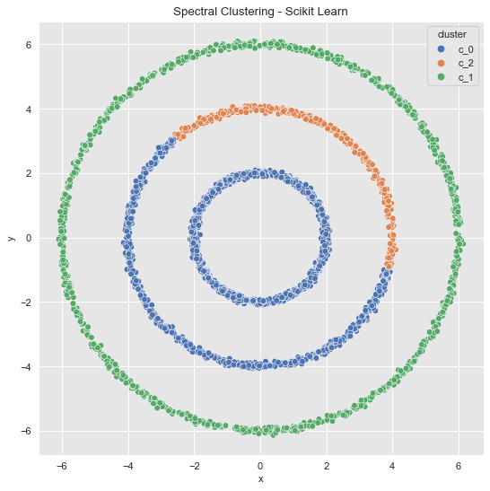

```python
data_df = data_frame_from_coordinates(coordinates_list[0])

spec_cl = SpectralClustering(
    n_clusters=3,
    random_state=25,
    n_neighbors=8,
    affinity='nearest_neighbors'
)

data_df['cluster'] = spec_cl.fit_predict(data_df[['x', 'y']])
data_df['cluster'] = ['c_' + str(c) for c in data_df['cluster']]

fig, ax = plt.subplots()
sns.scatterplot(x='x', y='y', data=data_df, hue='cluster', ax=ax)
ax.set(title='Spectral Clustering - Scikit Learn');
```

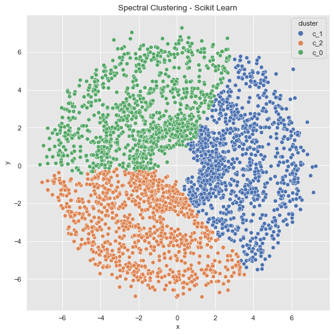

```python
data_df = data_frame_from_coordinates(coordinates_list[2])

spec_cl = SpectralClustering(
    n_clusters=3,
    random_state=25,
    n_neighbors=8,
    affinity='nearest_neighbors'
)

data_df['cluster'] = spec_cl.fit_predict(data_df[['x', 'y']])
data_df['cluster'] = ['c_' + str(c) for c in data_df['cluster']]

fig, ax = plt.subplots()
sns.scatterplot(x='x', y='y', data=data_df, hue='cluster', ax=ax)
ax.set(title='Spectral Clustering - Scikit Learn');
```

**Cuestión 5:** Compara los resultados con los que has obtenido en la PARTE 1. Explica especialmente lo que ocurre en el dataset con $$\sigma = 0.5$$. Escribe tu valoración en una caja abajo.

En el agrupamiento de la parte 1, se ajustan los parámetros de manera adecuada. El número de vecinos se selecciona correctamente para capturar la estructura anular de los datos. Además, la afinidad de vecino más cercano se utiliza de manera efectiva, permitiendo que el algoritmo capture las relaciones de vecindad relevantes.

Los resultados de este agrupamiento no tan bien hecho dan una mezcla de puntos entre los anillos y los clusters no siguen claramente la estructura anular de los datos. La visualización enseña una agrupación menos definida y con una mayor superposición entre los grupos.

Cuando se utiliza un sigma con valor 0.5 podemos ver una gran cantidad de ruido, por tanto, el agrupamiento resultante al aplicar el agrupamiento espetral es insatisfactorio.